# Ejemplo_Fake

# Presentación

En este post mostraré qué está afectando el desempeño en la educación cívica en el Perú, a nivel de sus provincias; según datos del 2017. Así hemos partido por proponer que la educación cívica es afectada por el nivel de desempeño escolar en habilidades cuantitativa y cualitativas , así como la relevancia estratégica de la provincia.

# Situación Regional

Veamos la situación regional desde el comportamiento de las variables independientes, utilizando análisis de clusters, siguiendo la técnica jerárquica.

El primer paso es preparar los datos para el análisis cluster.

```r
rm(list = ls())
# carga de datos
link='https://docs.google.com/spreadsheets/d/e/2PACX-1vQLNWEPcKqxX99PZi8rzvBLM9r0pI_z8O7tFSrbbps0MNF3F66sE90F6d9wNEnmxTZXi5zBQLy51prn/pub?gid=0&single=true&output=csv'
LosDatos=read.csv(link)

# variables a selecionar
varsHabi=c("LEC","ESC","MAT","CIE")
varsRelev=c("capital_depa","es_frontera","costa")

# cambiar texto a numero
a_0_1=function(x){ifelse(x=='no',0,1)}
LosDatos[,varsRelev]=lapply(LosDatos[,varsRelev],a_0_1)


# subset para clusterizar
paraCluster=LosDatos[,c(varsHabi,varsRelev)]


# cambio de nombre de fila
row.names(paraCluster)=LosDatos$PROVINCIA_2
```

Luego obtendremos los cuatro clusters sugeridos usando la técnica jerarquica divisiva (ver anexo 1):

```r
library(cluster)
library(factoextra)
set.seed(123)
g.dist = daisy(paraCluster, metric="gower")
res.diana <- hcut(g.dist, k = 4,hc_func='diana')
paraCluster$diana=res.diana$cluster
```

Para cada cluster, es es el comportamiento de las variables numericas:

```r
aggregate(data=paraCluster[,-c(5:7)],.~diana,FUN=mean)
```

| diana | LEC | ESC | MAT | CIE |
| --- | --- | --- | --- | --- |
| 1 | 51.34348 | 50.64783 | 48.81739 | 49.23043 |
| 2 | 49.60000 | 49.84966 | 49.58299 | 48.16871 |
| 3 | 45.71579 | 46.18947 | 45.16316 | 43.14737 |
| 4 | 54.17143 | 52.61429 | 51.78571 | 50.54286 |

Podemos recodificar estas variables:

```r
paraCluster$diana=dplyr::recode(paraCluster$diana, `1` = 3, `2`=2,`3`=1,`4`=4)
paraCluster$diana=as.ordered(paraCluster$diana)
```

El **dendograma** nos muestra el proceso de conglomeración:

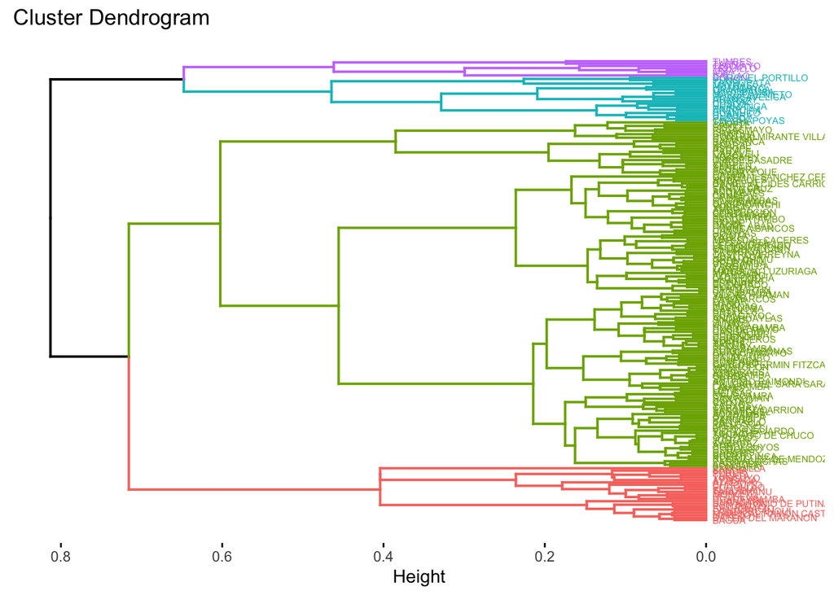

```r
# Visualize
fviz_dend(res.diana, cex = 0.4, horiz = T)
```

Una primera mirada a las provincias del Perú sería:

```r
library(sf)
```

```r
linkMapa='https://github.com/PoliticayGobiernoPUCP/data/raw/master/PROVINCIAS_peru.json'
mapaProv=read_sf(linkMapa)

paraCluster$PROVINCIA=row.names(paraCluster)
mapaProv=merge(mapaProv,paraCluster, by="PROVINCIA")
```

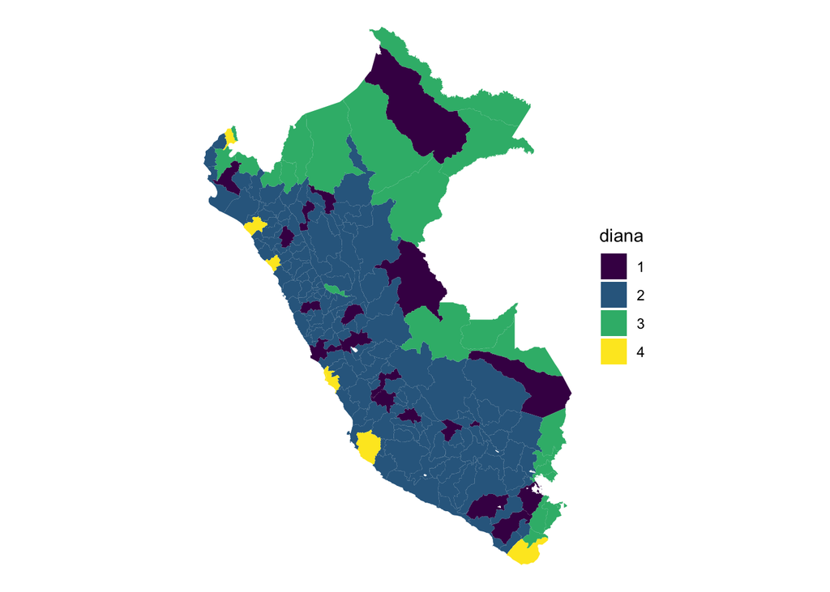

```r
library(ggplot2)

base= ggplot(data=mapaProv) + theme_void()
base + geom_sf(aes(fill=diana), color=NA)
```

# Preparación de latentes

Segun nuestro marco teórico tenemos tres latentes: habilidades cuali, habilidades cuanti y relevancia. En el Anexo 2 decidimos tratar sólo con una latente.

```r
model <- ' habilidad  =~ LEC + ESC + MAT + CIE'
```

Ahora vemos qué arroja el modelo:

```r
library(lavaan)
cfa_fit <- cfa(model, data=LosDatos,
           std.lv=TRUE,
           missing="fiml")
```

Preparo los tests:

```r
allParamCFA=parameterEstimates(cfa_fit,standardized = T)
allFitCFA=as.list(fitMeasures(cfa_fit))
```

Veamos resultados:

- Si cada indicador tiene una buena conexión con su latente (ver p valor):

```r
allParamCFA[allParamCFA$op=="=~",]
```

|  | lhs | op | rhs | est | se | z | pvalue | ci.lower | ci.upper | std.lv | std.all | std.nox |
| --- | --- | --- | --- | --- | --- | --- | --- | --- | --- | --- | --- | --- |
| 1 | habilidad | =~ | LEC | 9.269377 | 0.6060927 | 15.29366 | 0 | 8.081457 | 10.457297 | 9.269377 | 0.8870452 | 0.8870452 |
| 2 | habilidad | =~ | ESC | 8.176961 | 0.6314704 | 12.94908 | 0 | 6.939302 | 9.414621 | 8.176961 | 0.7952889 | 0.7952889 |
| 3 | habilidad | =~ | MAT | 8.366673 | 0.6029941 | 13.87522 | 0 | 7.184827 | 9.548520 | 8.366673 | 0.8335368 | 0.8335368 |
| 4 | habilidad | =~ | CIE | 8.559478 | 0.6322195 | 13.53878 | 0 | 7.320351 | 9.798606 | 8.559478 | 0.8185588 | 0.8185588 |

Averigüemos qué tan bien salió el modelo:

- El ChiSquare es NO significativo? (p_value debe ser mayor a 0.05 para que sea bueno)

```r
allFitCFA[c("chisq", "df", "pvalue")] # pvalue>0.05
```

```
## $chisq
## [1] 2.160874
##
## $df
## [1] 2
##
## $pvalue
## [1] 0.3394471
```

- El Índice Tucker Lewi es mayor a 0.9?

```r
allFitCFA$tli # > 0.90
```

```
## [1] 0.9989952
```

- La Raíz del error cuadrático medio de aproximación es menor a 0.05?

```r
allFitCFA[c('rmsea.ci.lower','rmsea' ,'rmsea.ci.upper')]
```

```
## $rmsea.ci.lower
## [1] 0
##
## $rmsea
## [1] 0.02025818
##
## $rmsea.ci.upper
## [1] 0.144637
```

Calculando.

```r
library(BBmisc)
scorescfa=normalize(lavPredict(cfa_fit),
                    method = "range",
                    margin=2, # by column
                    range = c(0, 10))
```

De ahi que:

```r
LosDatos$habilidad=scorescfa
```

La variable latente estratégica la calcularemos creando un indicador sumativo:

```r
LosDatos$relevancia=apply(LosDatos[,varsRelev],1,sum)
LosDatos$relevancia=as.ordered(LosDatos$relevancia)
```

# Regresión y prueba de hipotesis

```r
hipotesis=formula(CIV ~ habilidad + relevancia + pob)

resultado=lm(hipotesis,data = LosDatos)
summary(resultado)
```

```
##
## Call:
## lm(formula = hipotesis, data = LosDatos)
##
## Residuals:
##      Min       1Q   Median       3Q      Max
## -23.9396  -4.3154  -0.0751   4.7702  16.3596
##
## Coefficients:
##                Estimate Std. Error t value Pr(>|t|)
## (Intercept)   3.541e+01  1.680e+00  21.076  < 2e-16 ***
## habilidad     2.798e+00  1.931e-01  14.494  < 2e-16 ***
## relevancia.L -9.210e+00  3.341e+00  -2.756  0.00641 **
## relevancia.Q -1.108e+01  2.765e+00  -4.008  8.8e-05 ***
## relevancia.C -5.820e+00  2.014e+00  -2.891  0.00429 **
## pob          -1.420e-06  8.000e-07  -1.775  0.07752 .
## ---
## Signif. codes:  0 '***' 0.001 '**' 0.01 '*' 0.05 '.' 0.1 ' ' 1
##
## Residual standard error: 6.842 on 190 degrees of freedom
## Multiple R-squared:  0.5345, Adjusted R-squared:  0.5223
## F-statistic: 43.64 on 5 and 190 DF,  p-value: < 2.2e-16
```

# CONCLUSIONES

# ANEXOS

## Anexo 1: Exploración de clusters:

1. Saber si se transformará las variables numéricas:
- Sin modificación:

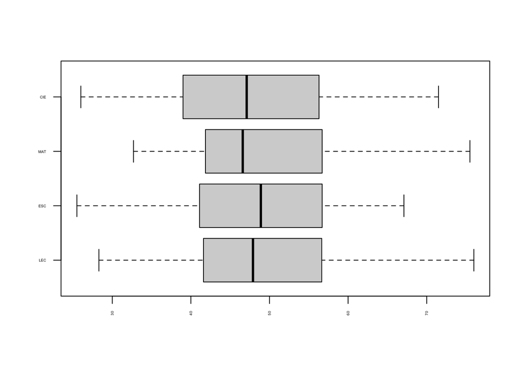

```r
boxplot(paraCluster[,varsHabi],horizontal=T,las=2,cex.axis=0.3)
```

- Tipificado:

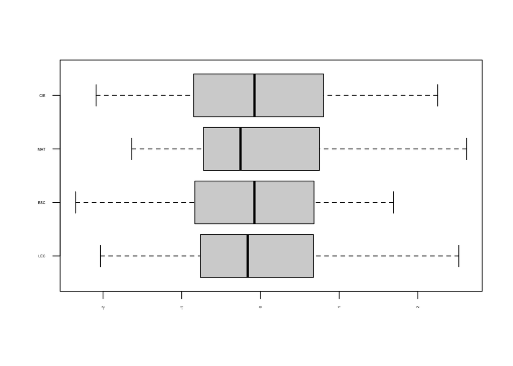

```r
boxplot(scale(paraCluster[,varsHabi]),horizontal=T,las=2,cex.axis=0.3)
```

- Suavizado logarítmicamente:

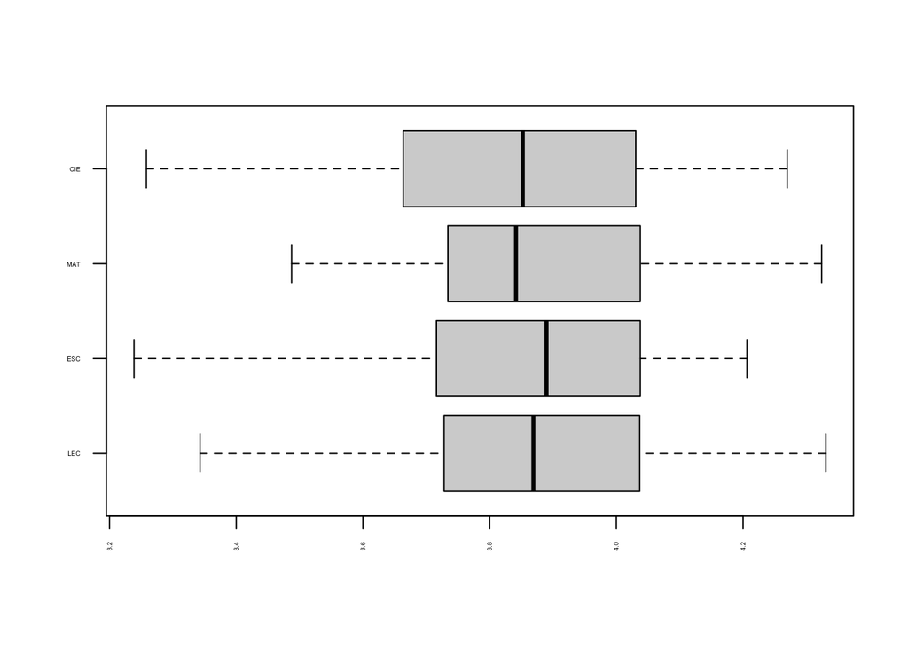

```r
boxplot(log(paraCluster[,varsHabi]),horizontal=T,las=2,cex.axis=0.3)
```

2. Saber cúanto clusters pedir

```r
library(cluster)
paraCluster=LosDatos[,c(varsHabi,varsRelev)]
set.seed(123)
g.dist = daisy(paraCluster, metric="gower")
```

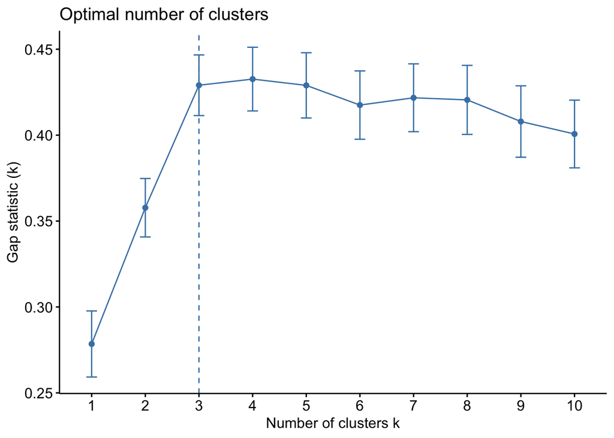

```r
## para PAM
set.seed(123)
library(factoextra)
fviz_nbclust(paraCluster, pam,diss=g.dist,method = "gap_stat",k.max = 10,verbose = F)
```

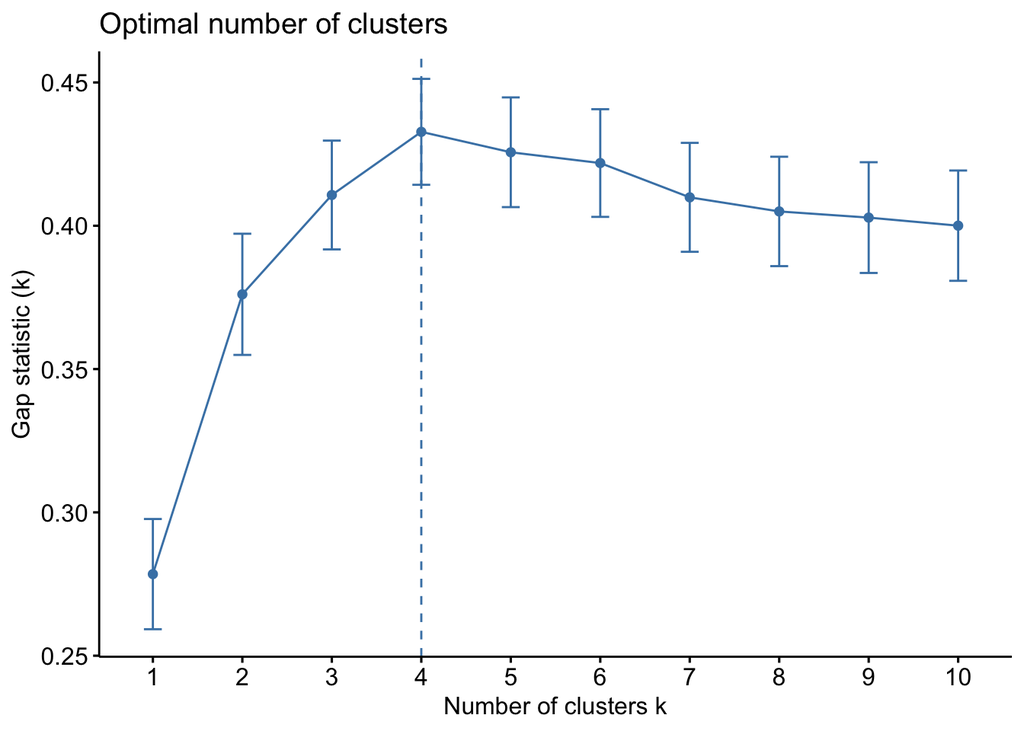

```r
## PARA JERARQUICO
set.seed(123)
fviz_nbclust(paraCluster, hcut,diss=g.dist,method = "gap_stat",k.max = 10,verbose = F,hc_func = "agnes")
```

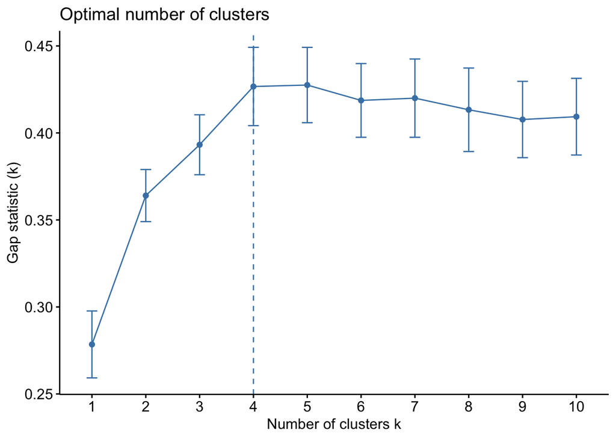

```r
## PARA JERARQUICO
set.seed(123)
fviz_nbclust(paraCluster, hcut,diss=g.dist,method = "gap_stat",k.max = 10,verbose = F,hc_func = "diana")
```

```r
set.seed(123)
SUGERIDOS=4
res.pam=pam(g.dist,k = SUGERIDOS,cluster.only = F)
res.agnes <- hcut(g.dist, k = SUGERIDOS,hc_func='agnes')
res.diana <- hcut(g.dist, k = SUGERIDOS,hc_func='diana')
```

- Evaluemos el resultado usando el coeficiente de *silueta*:
- Un caso se ha clusterizado bien si tiene valor positivo
- Un caso es dificilmente clusterizable si es muy cercano a cero
- Un caso está mal clusterizado si es negativo.

```
##   cluster size ave.sil.width
## 1       1   29          0.22
## 2       2   88          0.44
## 3       3   54          0.45
## 4       4   25          0.42
```

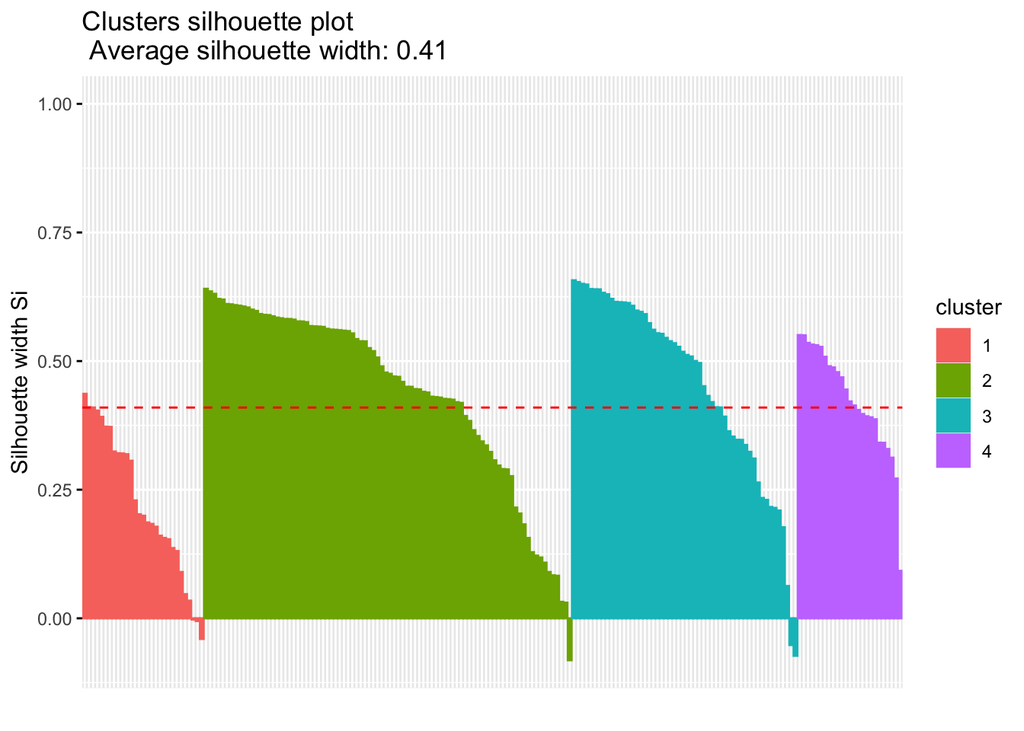

```r
fviz_silhouette(res.pam)
```

```
##   cluster size ave.sil.width
## 1       1   22          0.41
## 2       2   90          0.30
## 3       3   53          0.54
## 4       4   31          0.27
```

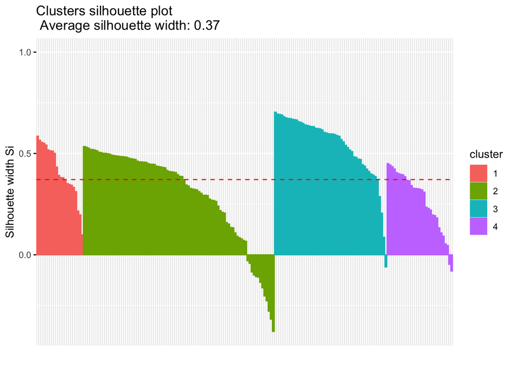

```r
fviz_silhouette(res.agnes)
```

```
##   cluster size ave.sil.width
## 1       1   23          0.50
## 2       2  147          0.36
## 3       3   19          0.39
## 4       4    7          0.38
```

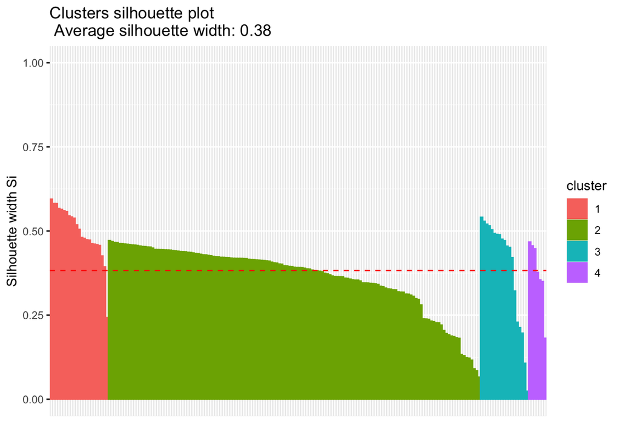

```r
fviz_silhouette(res.diana)
```

## Anexo 2: Exploración de latentes:

1. Calculando matriz de correlación:

```r
paraLat=paraCluster[,-c(8,9)]
# esta es:
library(polycor)
corMatrix=polycor::hetcor(paraLat)$correlations
```

2. Explorar correlaciones:
- Sin evaluar significancia:

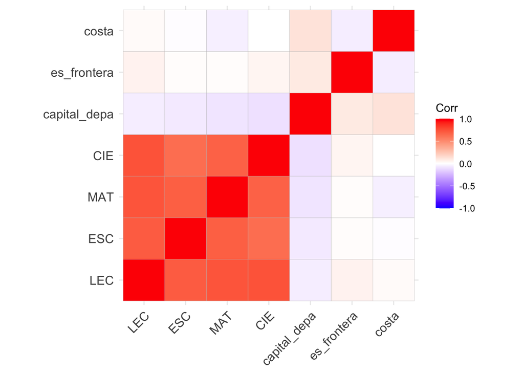

```r
library(ggcorrplot)

ggcorrplot(corMatrix)
```

Si puedes ver bloques correlacionados, hay esperanza de un buen analisis factorial.

3. Verificar si datos permiten factorizar:

```r
library(psych)
psych::KMO(corMatrix)
```

```
## Kaiser-Meyer-Olkin factor adequacy
## Call: psych::KMO(r = corMatrix)
## Overall MSA =  0.83
## MSA for each item =
##          LEC          ESC          MAT          CIE capital_depa  es_frontera
##         0.81         0.87         0.85         0.85         0.60         0.43
##        costa
##         0.39
```

4. Verificar si la matriz de correlaciones es adecuada

Aqui hay dos pruebas:

- Hnula: La matriz de correlacion es una [matriz identidad](https://en.wikipedia.org/wiki/Identity_matrix)

```r
cortest.bartlett(corMatrix,n=nrow(paraLat))$p.value>0.05
```

```
## [1] FALSE
```

- Hnula: La matriz de correlacion es una [matriz singular](http://mathworld.wolfram.com/SingularMatrix.html).

```r
library(matrixcalc)

is.singular.matrix(corMatrix)
```

```
## [1] FALSE
```

5. Determinar en cuantos factores o variables latentes podríamos redimensionar la data:

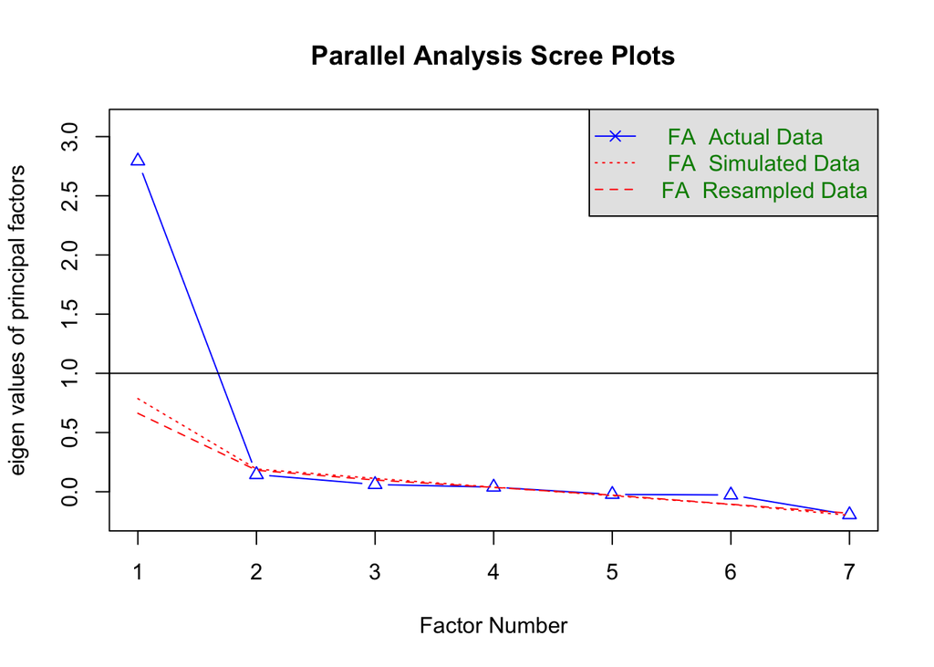

```
## Parallel analysis suggests that the number of factors =  1  and the number of components =  NA
```

```r
fa.parallel(paraLat,fm = 'ML', fa = 'fa',correct = T)
```

Se sugiere 1; pero esperabamos 2. Tratemos 2.

6. Redimensionar a numero menor de factores
- Resultado inicial:

```r
library(GPArotation)
resfa <- fa(paraLat,
            nfactors = 2,
            cor = 'mixed',
            rotate = "varimax",
            fm="minres")
```

```r
print(resfa$loadings)
```

```
##
## Loadings:
##              MR1    MR2
## LEC           0.890
## ESC           0.794
## MAT           0.836
## CIE           0.815
## capital_depa -0.145  0.993
## es_frontera          0.165
## costa                0.217
##
##                  MR1   MR2
## SS loadings    2.810 1.066
## Proportion Var 0.401 0.152
## Cumulative Var 0.401 0.554
```

- Resultado mejorado (solo apropiado si hay más de un factor):

```r
print(resfa$loadings,cutoff = 0.15)
```

```
##
## Loadings:
##              MR1    MR2
## LEC           0.890
## ESC           0.794
## MAT           0.836
## CIE           0.815
## capital_depa         0.993
## es_frontera          0.165
## costa                0.217
##
##                  MR1   MR2
## SS loadings    2.810 1.066
## Proportion Var 0.401 0.152
## Cumulative Var 0.401 0.554
```

- Resultado visual:

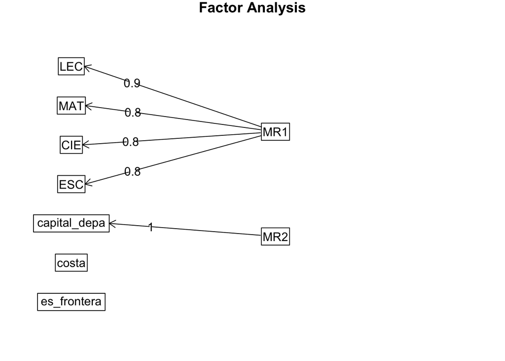

```r
fa.diagram(resfa)
```

7. Evaluando Resultado obtenido:
- ¿Qué variables aportaron mas a los factores?

```r
sort(resfa$communality)
```

```
##  es_frontera        costa          ESC          CIE          MAT          LEC
##   0.02993408   0.04766636   0.63055891   0.66539572   0.69966298   0.79414677
## capital_depa
##   1.00794930
```

- ¿Qué variables contribuyen a mas de un factor?

```r
sort(resfa$complexity)
```

```
##          ESC          MAT          CIE          LEC        costa capital_depa
##     1.000049     1.002402     1.003174     1.005371     1.021064     1.042529
##  es_frontera
##     1.187640
```

De ahí que sólo se podría pedir una latente.